# Aufgabe 10.3 – AI4I mit Seaborn visualisieren

**Status: APPROVED (26.10.2026).** Implementierung, Berechnungen und automatisierte Prüfung: Codex. Die studentische Bewertung ist in `reviews/exercise_10_3.md` unverändert dokumentiert. Die ausdrücklich bestätigte CI-Bedingung für die Freigabe ist erfüllt. Merge-Erlaubnis steht weiterhin aus.

[Offizielle Aufgabe](https://noxthot.github.io/ws26_industrial_datascience_manuscript/1_act1/6_self_study_session1.html), vollständig gelesen am 26.10.2026. Wir untersuchen alle 10.000 synthetischen Beobachtungen aus [UCI AI4I 2020](https://archive.ics.uci.edu/dataset/601/ai4i+2020+predictive+maintenance+dataset), DOI 10.24432/C5HS5C, CC BY 4.0. Quelle/Prüfsumme: `data/raw/README.md`.

Vorbereitung: `uv sync --locked`, `uv run python scripts/download_ai4i.py`. Reproduktion: `uv run python scripts/build_exercise_10_3.py`. Das Notebook verwendet danach nur lokale Daten. Die Aufgabe verlangt keinen PDF-Export; HTML und alle PNG-Figuren werden gespeichert. Keine 10.4-Quarto-Arbeit.

## Daten und Analyseentscheidungen

Der geprüfte Loader aus 10.2 kontrolliert unveränderte Rohbytes, Spalten, Zeilenzahl und Kennungen. `numeric` enthält ausschließlich die drei Messgrößen; UDI bleibt separat für die ausdrücklich verlangte Linie. Keine Imputation, Normalisierung, Filterung oder Stichprobe. UDI ist **kein Zeitstempel**. Ein Seed reproduziert nur den Jitter, nicht eine vermeintliche Messunsicherheit.

```python
from pathlib import Path
import os
import sys
import json

root = next(p for p in (Path.cwd(), *Path.cwd().parents)
            if (p / "pyproject.toml").exists())
sys.path.insert(0, str(root)) if str(root) not in sys.path else None
os.environ.setdefault("MPLCONFIGDIR", str(root / ".tools/matplotlib"))
import matplotlib
matplotlib.use("Agg")
import matplotlib.pyplot as plt
import numpy as np
import pandas as pd
import seaborn as sns
from IPython.display import display, Image, Markdown
from sessions.ch10.ai4i_data import load_ai4i, verify_file
from sessions.ch10.ai4i_eda import (
    MEASUREMENTS, TORQUE, SPEED, AIR, SEED, add_bins,
    iqr_summary, strongest_pair,
)

data = load_ai4i()
numeric = data.loc[:, MEASUREMENTS].copy()
assert numeric.shape == (10000, 3)
out = root / "outputs/ch10/exercise_10_3"
out.mkdir(parents=True, exist_ok=True)
np.random.seed(SEED)
sns.set_theme(style="whitegrid", context="notebook")

def save_show(fig, name):
    path = out / f"{name}.png"
    fig.savefig(path, dpi=140, bbox_inches="tight")
    display(Image(filename=str(path)))
    plt.close(fig)

print(f"Daten: {len(data)} Zeilen, drei Messgrößen; Seaborn {sns.__version__}")
print(f"SHA256: {verify_file()}")
display(numeric.describe())
```

```
Daten: 10000 Zeilen, drei Messgrößen; Seaborn 0.13.2
SHA256: dc6630cd9b1f0f853922fad78a1b6436570d3f1ec863f1dd5c4340ac56bc8a8e
```

|  | Torque [Nm] | Rotational speed [rpm] | Air temperature [K] |
| --- | --- | --- | --- |
| count | 10000.000000 | 10000.000000 | 10000.000000 |
| mean | 39.986910 | 1538.776100 | 300.004930 |
| std | 9.968934 | 179.284096 | 2.000259 |
| min | 3.800000 | 1168.000000 | 295.300000 |
| 25% | 33.200000 | 1423.000000 | 298.300000 |
| 50% | 40.100000 | 1503.000000 | 300.100000 |
| 75% | 46.800000 | 1612.000000 | 301.500000 |
| max | 76.600000 | 2886.000000 | 304.500000 |

## 1. Drehmoment über UDI

Die Linie verbindet alle Beobachtungen in Originalreihenfolge. `estimator=None` verhindert Aggregation; es wird kein Unsicherheitsband dargestellt. Dichte Schwankungen über eine Zeilenkennung dürfen nicht als zeitlicher Prozess interpretiert werden.

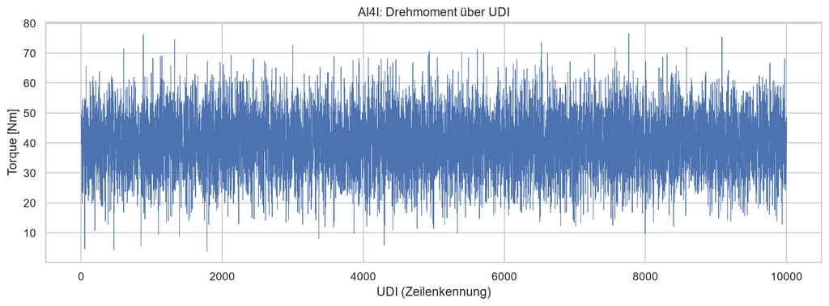

```python
fig, ax = plt.subplots(figsize=(11, 4), layout="constrained")
sns.lineplot(data=data, x="UDI", y=TORQUE, estimator=None,
             errorbar=None, sort=False, linewidth=0.5, ax=ax)
ax.set(title="AI4I: Drehmoment über UDI", xlabel="UDI (Zeilenkennung)",
       ylabel=TORQUE)
save_show(fig, "01_line")
```

## 2. Verteilungen – Histogramme

Je Messgröße werden 30 Bins verwendet. Anzahl und Grenzen der Bins beeinflussen den visuellen Eindruck. Die x-Achsen behalten ihre Einheiten und eigenen Skalen; die y-Achsen zählen Beobachtungen, nicht Wahrscheinlichkeitsdichten.

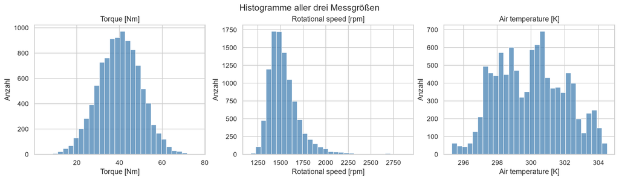

```python
fig, axes = plt.subplots(1, 3, figsize=(14, 4), layout="constrained")
for ax, column in zip(axes, MEASUREMENTS):
    sns.histplot(data=numeric, x=column, bins=30, ax=ax, color="steelblue")
    ax.set(title=column, xlabel=column, ylabel="Anzahl")
fig.suptitle("Histogramme aller drei Messgrößen")
save_show(fig, "02_histograms")
```

## 3. Boxplots und auffällige Werte

Boxplots verdichten Median, Quartile und Streuung. Punkte außerhalb der 1,5-IQR-Zäune sind hier **heuristisch auffällig**, nicht automatisch fehlerhaft. Die jeweilige Messgröße erhält eine eigene Achse mit Originaleinheit.

Numerische Randfälle: Die Berechnung nutzt eine absolute Toleranz von 1e-10 in der jeweiligen Einheit; der Boxplot verwendet `whis=1.5+1e-12`, um Werte auf den theoretischen Zäunen nicht durch Rundungsfehler als außerhalb zu zeigen. Diese Änderungen sind gegenüber der Messauflösung vernachlässigbar. Bei Torque liegen vier Werte auf 12,8 und einer auf 67,2 Nm; sie gelten nicht als Ausreißer.

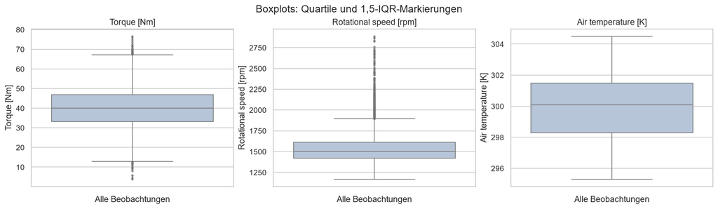

|  | q1 | q3 | lower_fence | upper_fence | flagged_count | skewness | minimum | maximum |
| --- | --- | --- | --- | --- | --- | --- | --- | --- |
| Torque [Nm] | 33.2 | 46.8 | 12.8 | 67.2 | 64 | -0.009517 | 3.8 | 76.6 |
| Rotational speed [rpm] | 1423.0 | 1612.0 | 1139.5 | 1895.5 | 418 | 1.993171 | 1168.0 | 2886.0 |
| Air temperature [K] | 298.3 | 301.5 | 293.5 | 306.3 | 0 | 0.114274 | 295.3 | 304.5 |

```python
fig, axes = plt.subplots(1, 3, figsize=(14, 4), layout="constrained")
for ax, column in zip(axes, MEASUREMENTS):
    sns.boxplot(data=numeric, y=column, whis=1.5 + 1e-12, fliersize=2, ax=ax,
                color="lightsteelblue")
    ax.set(title=column, ylabel=column, xlabel="Alle Beobachtungen")
fig.suptitle("Boxplots: Quartile und 1,5-IQR-Markierungen")
save_show(fig, "03_boxplots")
iqr = iqr_summary(numeric)
iqr.to_csv(out / "iqr_summary.csv")
display(iqr)
```

## 4. Violinplots im Vergleich zu Boxplots

Die Violinbreite ist eine Kernel-Dichteschätzung (KDE), keine Anzahl einzelner Beobachtungen. Bandbreite und Stichprobe beeinflussen die Form. `cut=0` begrenzt die Darstellung auf beobachtete Werte; innere Quartile ergänzen die Dichte. Gegenüber Boxplots wird Verteilungsform sichtbar, aber auch geglättet und damit von einer zusätzlichen Modellierungsentscheidung abhängig.

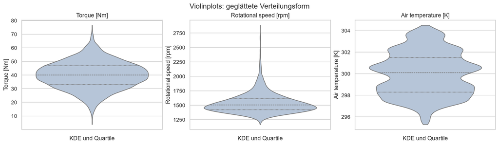

```python
fig, axes = plt.subplots(1, 3, figsize=(14, 4), layout="constrained")
for ax, column in zip(axes, MEASUREMENTS):
    sns.violinplot(data=numeric, y=column, cut=0, bw_adjust=1,
                   inner="quart", color="lightsteelblue", ax=ax)
    ax.set(title=column, ylabel=column, xlabel="KDE und Quartile")
fig.suptitle("Violinplots: geglättete Verteilungsform")
save_show(fig, "04_violins")
```

## 5. Torque gegen Rotational speed – Temperatur als Farbe

`sns.scatterplot` bildet Drehzahl auf x, Drehmoment auf y und Lufttemperatur auf die kontinuierliche Farbskala ab. Transparenz begrenzt die Überlagerung aller 10.000 Punkte. Die Farblegende zeigt Kelvin; Farbunterschiede beweisen keinen Einfluss der Temperatur.

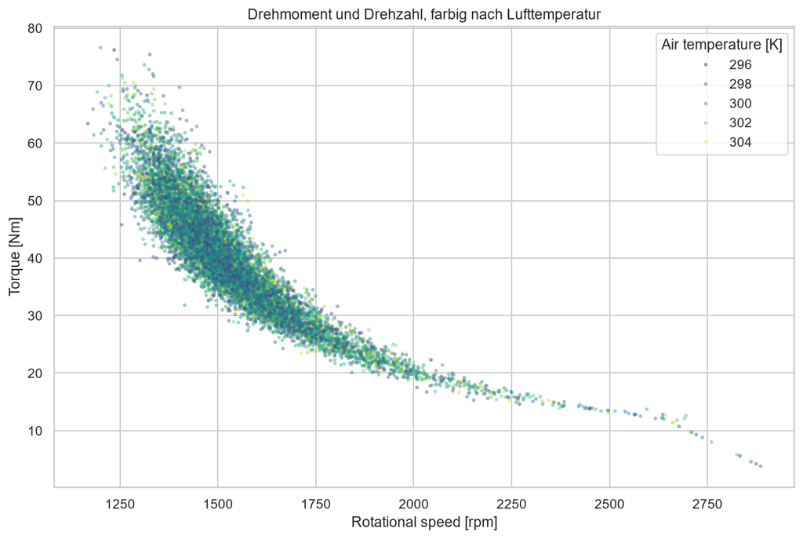

```python
fig, ax = plt.subplots(figsize=(9, 6), layout="constrained")
sns.scatterplot(data=data, x=SPEED, y=TORQUE, hue=AIR, palette="viridis",
                s=9, alpha=0.45, linewidth=0, legend="brief", ax=ax)
ax.set(title="Drehmoment und Drehzahl, farbig nach Lufttemperatur")
ax.legend(title=AIR)
save_show(fig, "05_scatter")
```

## 6. Paarweise Beziehungen

`sns.pairplot` zeigt alle drei Messgrößen, ihre paarweisen Punktwolken und Histogramme auf der Diagonalen. Unterschiedliche Achsenskalierungen sind nötig, weil Einheiten und Wertebereiche verschieden sind. Alle Beobachtungen werden verwendet; dichte Bereiche können sich weiterhin überdecken.

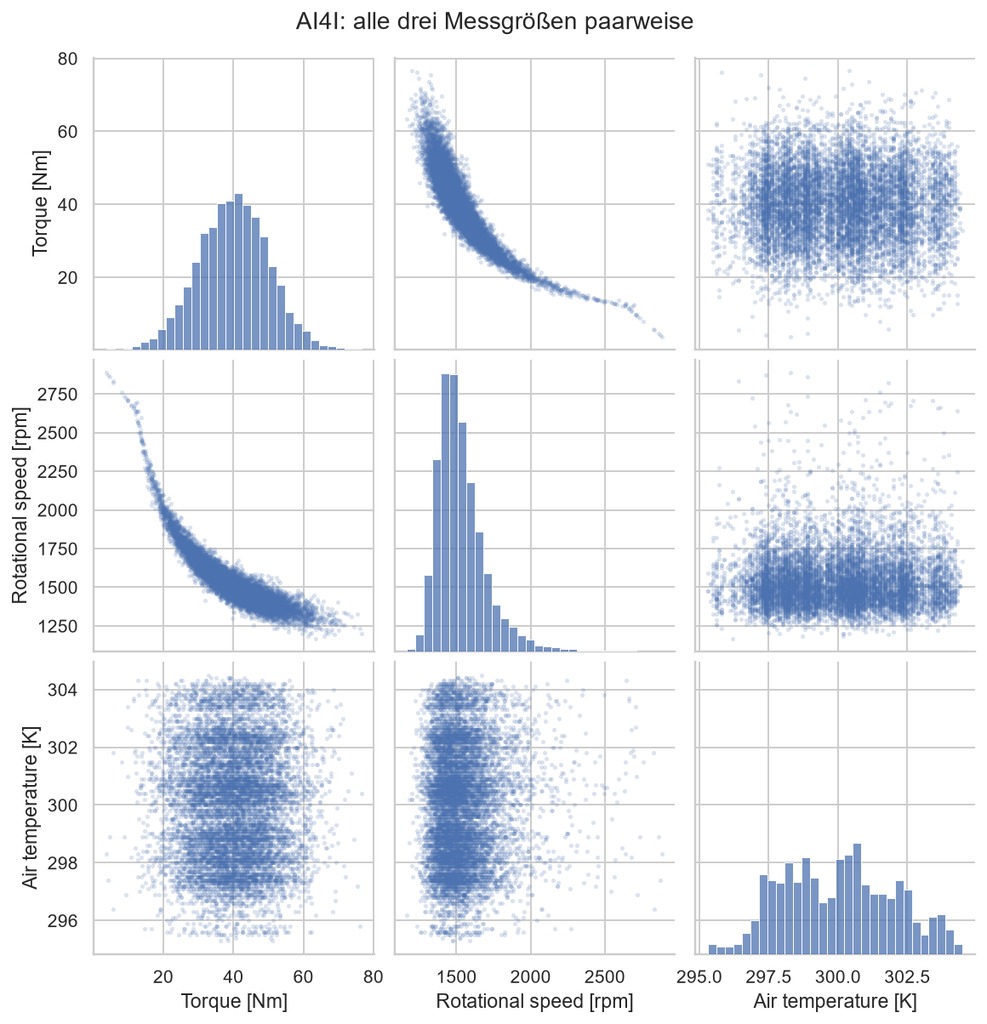

```python
grid = sns.pairplot(data=numeric, vars=MEASUREMENTS, diag_kind="hist",
                    height=2.8, plot_kws={"s": 7, "alpha": 0.2, "linewidth": 0},
                    diag_kws={"bins": 30})
grid.figure.suptitle("AI4I: alle drei Messgrößen paarweise", y=1.02)
save_show(grid.figure, "06_pairplot")
```

## 7. Korrelation

Pearson misst den linearen Zusammenhang. Die Heatmap verwendet die feste Skala −1 bis +1 und annotiert alle Koeffizienten. Das stärkste Paar wird nach dem Betrag der Off-Diagonale gewählt. Spearman ergänzt die Betrachtung monotoner, möglicherweise nichtlinearer Muster. Keine Korrelation belegt Kausalität.

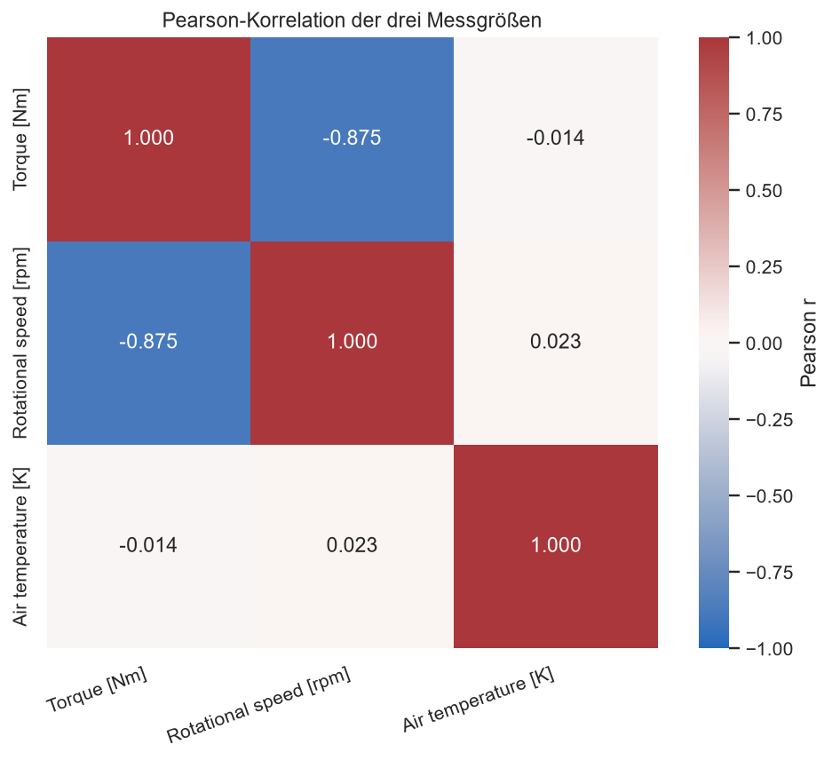

|  | Torque [Nm] | Rotational speed [rpm] | Air temperature [K] |
| --- | --- | --- | --- |
| Torque [Nm] | 1.000000 | -0.916474 | -0.011765 |
| Rotational speed [rpm] | -0.916474 | 1.000000 | 0.013732 |
| Air temperature [K] | -0.011765 | 0.013732 | 1.000000 |

Stärkstes Pearson-Paar: **Torque [Nm] / Rotational speed [rpm]**, r = **-0.8750**. Spearman dafür: **-0.9165**.

```python
pearson = numeric.corr(method="pearson")
spearman = numeric.corr(method="spearman")
pearson.to_csv(out / "pearson.csv")
spearman.to_csv(out / "spearman.csv")
fig, ax = plt.subplots(figsize=(8, 6), layout="constrained")
sns.heatmap(pearson, annot=True, fmt=".3f", vmin=-1, vmax=1,
            center=0, cmap="vlag", square=True, ax=ax,
            cbar_kws={"label": "Pearson r"})
ax.set_title("Pearson-Korrelation der drei Messgrößen")
ax.set_xticklabels(ax.get_xticklabels(), rotation=20, ha="right")
save_show(fig, "07_heatmap")
display(spearman)
a, b, r = strongest_pair(pearson)
display(Markdown(f"Stärkstes Pearson-Paar: **{a} / {b}**, r = **{r:.4f}**. "
                 f"Spearman dafür: **{spearman.loc[a, b]:.4f}**."))
```

## 8. Jointplot mit Regressionsgerade

Torque wird gegen Air temperature geplottet, inklusive Randverteilungen. Die Gerade ist eine deskriptive lineare Zusammenfassung, kein Kausalmodell. Ein Konfidenzband wird weggelassen (`ci=None`), da hier keine ungeprüfte Unabhängigkeitsannahme in eine inferenzstatistische Aussage übersetzt werden soll.

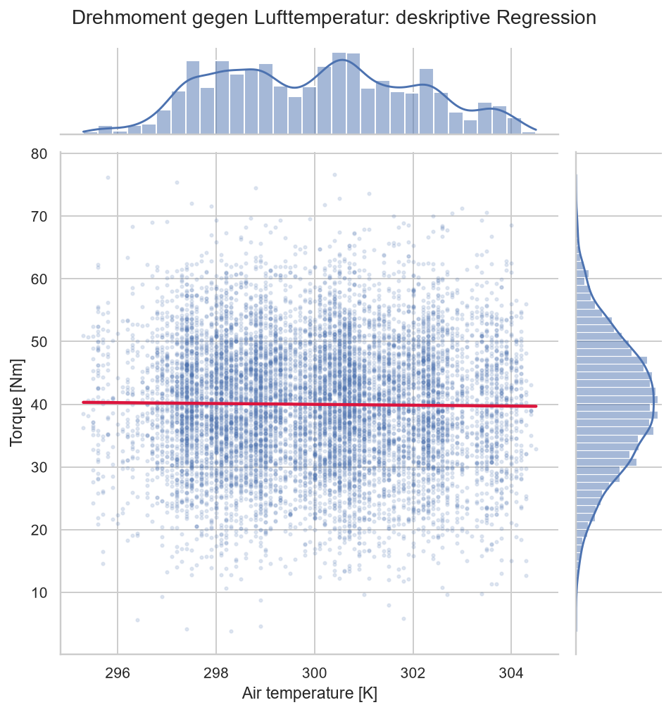

```python
grid = sns.jointplot(data=numeric, x=AIR, y=TORQUE, kind="reg", height=7,
                     joint_kws={"ci": None,
                                 "scatter_kws": {"s": 5, "alpha": 0.15},
                                 "line_kws": {"color": "crimson"}})
grid.figure.suptitle("Drehmoment gegen Lufttemperatur: deskriptive Regression", y=1.03)
save_show(grid.figure, "08_joint_regression")
```

## 9. Stripplot nach Drehzahl-Bins

`pd.cut` teilt den beobachteten Drehzahlbereich in drei Intervalle gleicher Breite, benannt low/medium/high. Das sind **keine Quantile**; Gruppengrößen dürfen sich stark unterscheiden. Die exakten Grenzen und Häufigkeiten werden ausgegeben. Alle Drehmomentwerte erscheinen als Punkte, Farbe und x-Position kennzeichnen denselben Bin. Jitter (Seed 42) dient ausschließlich der Darstellung.

| speed_band | lower | upper | count |
| --- | --- | --- | --- |
| low | 1166.282000 | 1740.666667 | 8965 |
| medium | 1740.666667 | 2313.333333 | 975 |
| high | 2313.333333 | 2886.000000 | 60 |

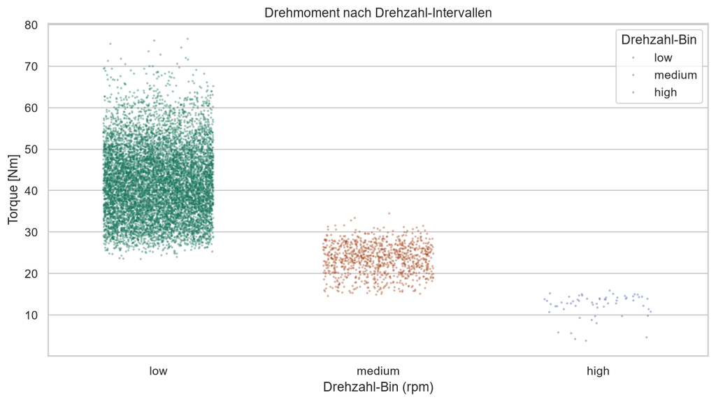

```python
binned, edges = add_bins(data)
(out / "bin_edges.json").write_text(json.dumps(edges, indent=2), encoding="utf-8")
speed_counts = binned["speed_band"].value_counts(sort=False)
speed_counts.to_csv(out / "speed_bin_counts.csv", header=["count"])
display(pd.DataFrame({"lower": edges["speed_edges"][:-1],
                      "upper": edges["speed_edges"][1:],
                      "count": speed_counts.to_numpy()}, index=speed_counts.index))
np.random.seed(SEED)
fig, ax = plt.subplots(figsize=(9, 5), layout="constrained")
sns.stripplot(data=binned, x="speed_band", y=TORQUE, hue="speed_band",
              order=["low", "medium", "high"], hue_order=["low", "medium", "high"],
              palette=["#19765b", "#a54318", "#4055a8"], jitter=0.25, alpha=0.4, size=2, legend="full", ax=ax)
ax.set(title="Drehmoment nach Drehzahl-Intervallen", xlabel="Drehzahl-Bin (rpm)", ylabel=TORQUE)
ax.legend(title="Drehzahl-Bin")
save_show(fig, "09_strip")
```

## 10. Countplot der Torque-Intervalle

Die zehn Intervalle gleicher Breite decken alle Drehmomentwerte ab; die Intervallgrenzen sind zusätzlich als JSON gespeichert. `pd.cut` erweitert bei ganzzahliger Bin-Anzahl den Rand leicht, damit die Extremwerte eingeschlossen sind. Der Countplot zählt alle 10.000 Zeilen ohne Filterung.

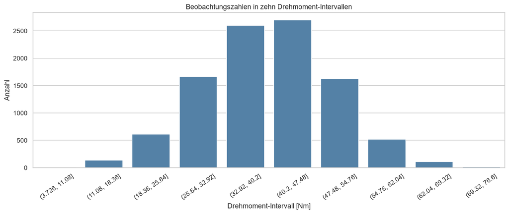

| torque_band | count |
| --- | --- |
| (3.726, 11.08] | 13 |
| (11.08, 18.36] | 137 |
| (18.36, 25.64] | 614 |
| (25.64, 32.92] | 1666 |
| (32.92, 40.2] | 2597 |
| (40.2, 47.48] | 2697 |
| (47.48, 54.76] | 1624 |
| (54.76, 62.04] | 521 |
| (62.04, 69.32] | 112 |
| (69.32, 76.6] | 19 |

```python
torque_counts = binned["torque_band"].value_counts(sort=False)
assert int(torque_counts.sum()) == len(data)
torque_counts.to_csv(out / "torque_bin_counts.csv", header=["count"])
fig, ax = plt.subplots(figsize=(12, 5), layout="constrained")
sns.countplot(data=binned, x="torque_band", order=binned["torque_band"].cat.categories,
              color="steelblue", ax=ax)
ax.set(title="Beobachtungszahlen in zehn Drehmoment-Intervallen",
       xlabel="Drehmoment-Intervall [Nm]", ylabel="Anzahl")
ax.tick_params(axis="x", labelrotation=35)
save_show(fig, "10_count")
display(torque_counts.to_frame("count"))
```

## Beobachtungen – tatsächlich berechnete Kennzahlen

Die folgende Tabelle ergänzt die visuelle Beurteilung mit reproduzierbaren Kennzahlen. IQR-Flags werden nicht entfernt. Skewness beschreibt Asymmetrie, ist aber weder Normalitätstest noch Beleg einer bestimmten Verteilung.

```python
display(iqr[["flagged_count", "skewness", "minimum", "maximum"]])
display(Markdown(
    f"**Auffällige Werte:** Torque {int(iqr.loc[TORQUE, 'flagged_count'])}, "
    f"Rotational speed {int(iqr.loc[SPEED, 'flagged_count'])}, "
    f"Air temperature {int(iqr.loc[AIR, 'flagged_count'])} außerhalb der 1,5-IQR-Zäune. "
    f"**Stärkste Beziehung:** {a} / {b}, Pearson r = {r:.4f}. "
    f"Drehmoment-Skewness {iqr.loc[TORQUE, 'skewness']:.3f}, "
    f"Drehzahl-Skewness {iqr.loc[SPEED, 'skewness']:.3f}, "
    f"Temperatur-Skewness {iqr.loc[AIR, 'skewness']:.3f}."
))
```

|  | flagged_count | skewness | minimum | maximum |
| --- | --- | --- | --- | --- |
| Torque [Nm] | 64 | -0.009517 | 3.8 | 76.6 |
| Rotational speed [rpm] | 418 | 1.993171 | 1168.0 | 2886.0 |
| Air temperature [K] | 0 | 0.114274 | 295.3 | 304.5 |

**Auffällige Werte:** Torque 64, Rotational speed 418, Air temperature 0 außerhalb der 1,5-IQR-Zäune. **Stärkste Beziehung:** Torque [Nm] / Rotational speed [rpm], Pearson r = -0.8750. Drehmoment-Skewness -0.010, Drehzahl-Skewness 1.993, Temperatur-Skewness 0.114.

## Beobachtete Muster und Grenzen

Die folgenden Aussagen wurden nach tatsächlicher Ausführung und Sichtprüfung von Codex formuliert und sind keine studentische Beurteilung:

1. **Auffällige Werte:** Die Boxplots zeigen Randwerte bei Torque und vor allem im oberen Drehzahlbereich. Mit der dokumentierten Randtoleranz werden 64 Torque-, 418 Drehzahl- und 0 Temperaturwerte markiert. Das sind Heuristiken, keine bewiesenen Fehler; kein Wert wird entfernt.
2. **Stärkste Beziehung:** Torque und Rotational speed sind deutlich negativ verbunden (Pearson −0,8750; Spearman −0,9165). Scatter und Pairplot zeigen eine gekrümmte, monoton fallende Punktwolke. Ein linearer Koeffizient fasst diese Form nur teilweise zusammen. Die Temperatur-Korrelationen liegen dagegen nahe null; die Jointplot-Gerade ist nahezu horizontal. Das beweist weder völlige Unabhängigkeit noch einen fehlenden physikalischen Einfluss.
3. **Verteilungsformen:** Torque ist ungefähr symmetrisch und glockenförmig (Skewness −0,010); Normalität ist damit nicht bewiesen. Die Drehzahl hat einen langen rechten Schwanz (Skewness 1,993). Temperatur zeigt mehrere unregelmäßige Häufungen trotz kleiner Schiefe (0,114); kleine Schiefe allein bedeutet keine Normalverteilung.
4. **Binning und Darstellung:** Die drei gleichbreiten Drehzahlgruppen enthalten 8965/975/60 Beobachtungen. Der Stripplot verdeutlicht sinkende Torque-Werte über diese Gruppen, aber keine kontrollierten Effekte. Histogramm-Bins und KDE-Bandbreite beeinflussen die sichtbare Form; insbesondere Violinbreiten sind keine direkten Häufigkeiten. Transparenz/Jitter beseitigen Überlagerung nicht vollständig.

Die Daten sind synthetisch, UDI ist kein Zeitstempel. Es werden weder Kausalität, Signifikanz noch ein zugrunde liegender Mechanismus nachgewiesen. Regression und Korrelationsmatrizen sind rein deskriptiv. Die positive studentische Prüfung und ihre erfüllte CI-Freigabebedingung sind separat dokumentiert.

## Fragen für Human Review

1. Sind alle verlangten Diagramme und alle drei Messgrößen vorhanden und lesbar?
2. Wie unterscheiden sich Boxplot und Violinplot, und warum sind IQR-Flags keine bewiesenen Fehler?
3. Was zeigen Scatter, Pairplot und Pearson/Spearman über die stärkste Beziehung und mögliche Nichtlinearität?
4. Wie beeinflussen gleiche Bin-Breiten, ungleiche Gruppengrößen, Jitter und KDE die Darstellung?
5. Welche Schlussfolgerungen sind wegen synthetischer Daten und fehlender Zeitinformation nicht zulässig?

**APPROVED nach erfüllter studentischer CI-Bedingung. Kein Merge, keine automatische Abgabe.**